# Reproducible Research Week 2 Assignment

Anupam Acharya

16 August 2018

Reading data and displaying a summary of the data.

```r
alldata <- read.csv("./repdata%2Fdata%2Factivity/activity.csv")
alldata$date <- as.Date(alldata$date)
alldata$weekday <- factor(weekdays(alldata$date), levels = c("Monday", "Tuesday", "Wednesday", "Thursday", "Friday", "Saturday", "Sunday"))
head(alldata)
```

```
##   steps       date interval weekday
## 1    NA 2012-10-01        0  Monday
## 2    NA 2012-10-01        5  Monday
## 3    NA 2012-10-01       10  Monday
## 4    NA 2012-10-01       15  Monday
## 5    NA 2012-10-01       20  Monday
## 6    NA 2012-10-01       25  Monday
```

```r
summary(alldata$steps)
```

```
##    Min. 1st Qu.  Median    Mean 3rd Qu.    Max.    NA's
##    0.00    0.00    0.00   37.38   12.00  806.00    2304
```

### What is mean total number of steps taken per day?

#### 1. Calculate the total number of steps taken per day

```r
total_steps_daywise <- tapply(alldata$steps, alldata$date, sum)
head(total_steps_daywise)
```

```
## 2012-10-01 2012-10-02 2012-10-03 2012-10-04 2012-10-05 2012-10-06
##         NA        126      11352      12116      13294      15420
```

#### 2. Make a histogram of the total number of steps taken each day

I have used the base plot system to create a histogram of the total number of steps taken each day.

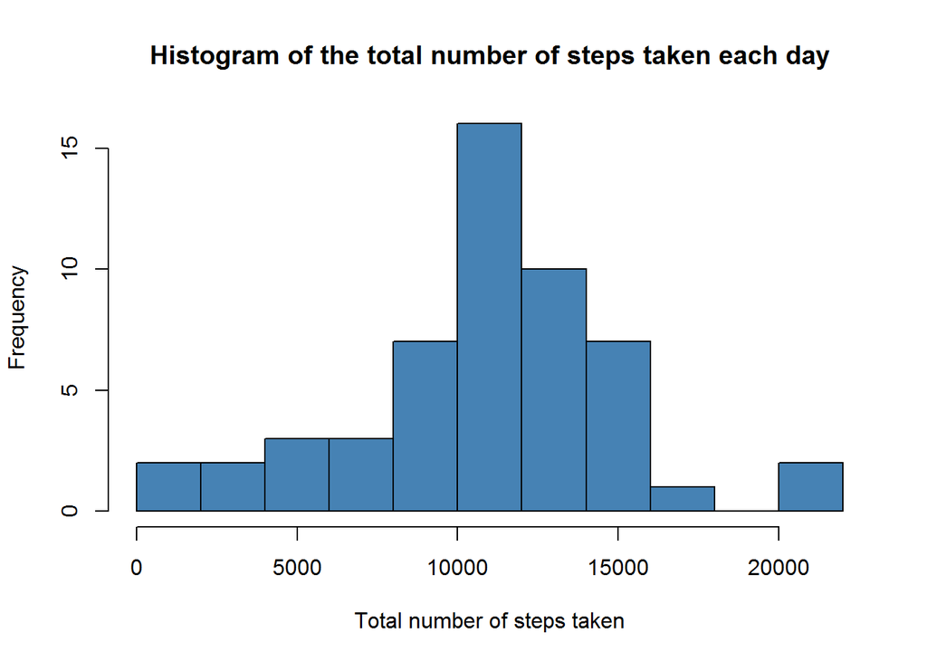

```r
hist(total_steps_daywise, main = "Histogram of the total number of steps taken each day", xlab = "Total number of steps taken", ylab = "Frequency", col = "steel blue", breaks = 10)
```

```r
mean <- round(mean(total_steps_daywise, na.rm = TRUE), digits = 1)
median <- round(median(total_steps_daywise, na.rm = TRUE), digits = 1)
```

### What is the average daily activity pattern?

#### 1. Make a time series plot (i.e. type = “l”) of the 5-minute interval (x-axis) and the average number of steps taken, averaged across all days (y-axis)

Calculating the mean of total steps for every 5-minute interval.

```r
total_steps_intervalwise <- tapply(alldata$steps, alldata$interval, mean, na.rm = TRUE)
```

Plotting the line diagram

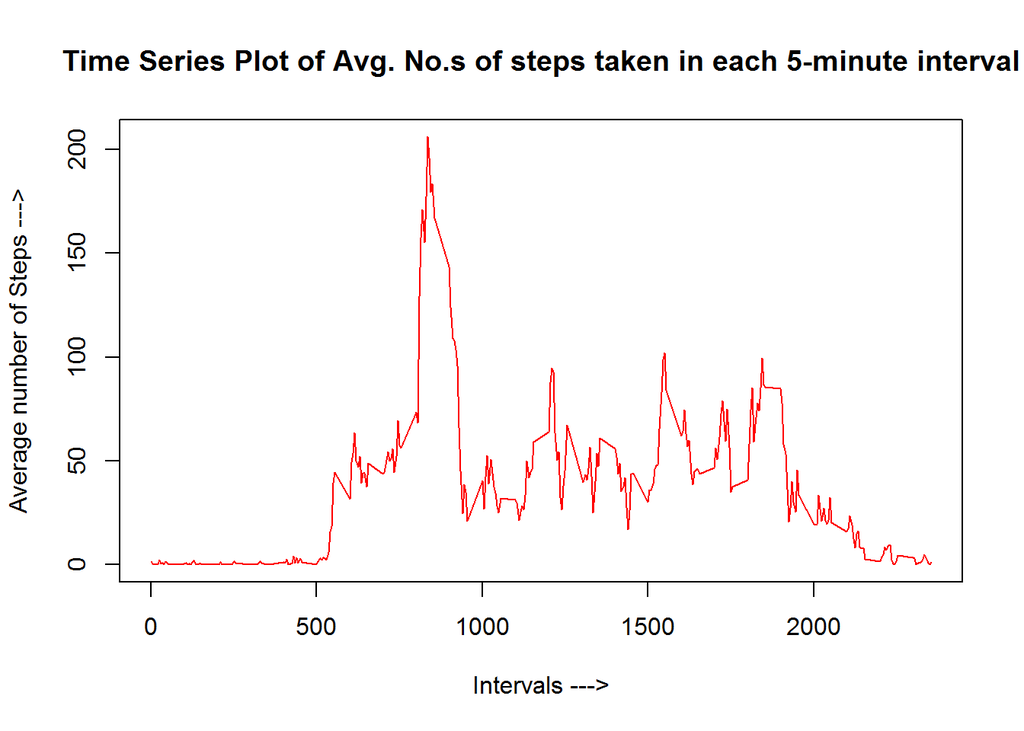

```r
plot(alldata$interval[1:288], total_steps_intervalwise, col = "red", main = "Time Series Plot of Avg. No.s of steps taken in each 5-minute interval", xlab = "Intervals --->", ylab = "Average number of Steps --->", type = "l")
```

```r
max <- alldata$interval[which(total_steps_intervalwise == max(total_steps_intervalwise), )]
```

### Imputing missing values

#### 1. Calculate and report the total number of missing values in the dataset (i.e. the total number of rows with NAs)

```r
nas <- sum(is.na(alldata$steps))
```

The total number of rows with NAs are 2304

#### 2. Devise a strategy for filling in all of the missing values in the dataset. The strategy does not need to be sophisticated. For example, you could use the mean/median for that day, or the mean for that 5-minute interval, etc.

The strategy for filling in all of the missing values in the dataset in the steps column is to mutate the mean of steps for that 5 minute interval to each NA value. The data have to be grouped by interval and calculated mean for that interval will have to be overwritten on the NA value.

#### 3. Create a new dataset that is equal to the original dataset but with the missing data filled in.

The above strategy has been applied to create the new dataset. The new data set is called imputed_data.

```r
#loading libraries
library(dplyr)
#Function to identify if a value is NA and calculate the mean.
mean_steps <- function(num) replace(num, is.na(num), mean(num, na.rm = TRUE))
#Data Imputed with the above strategy
imputed_data <- alldata %>% group_by(interval) %>% mutate(steps = mean_steps(steps))
#Displaying Imputed data
head(imputed_data)
```

```
## # A tibble: 6 x 4
## # Groups:   interval [6]
##    steps date       interval weekday
##    <dbl> <date>        <int> <fct>
## 1 1.72   2012-10-01        0 Monday
## 2 0.340  2012-10-01        5 Monday
## 3 0.132  2012-10-01       10 Monday
## 4 0.151  2012-10-01       15 Monday
## 5 0.0755 2012-10-01       20 Monday
## 6 2.09   2012-10-01       25 Monday
```

```r
summary(imputed_data)
```

```
##      steps             date               interval           weekday
##  Min.   :  0.00   Min.   :2012-10-01   Min.   :   0.0   Monday   :2592
##  1st Qu.:  0.00   1st Qu.:2012-10-16   1st Qu.: 588.8   Tuesday  :2592
##  Median :  0.00   Median :2012-10-31   Median :1177.5   Wednesday:2592
##  Mean   : 37.38   Mean   :2012-10-31   Mean   :1177.5   Thursday :2592
##  3rd Qu.: 27.00   3rd Qu.:2012-11-15   3rd Qu.:1766.2   Friday   :2592
##  Max.   :806.00   Max.   :2012-11-30   Max.   :2355.0   Saturday :2304
##                                                         Sunday   :2304
```

```r
new_nas <- sum(is.na(imputed_data$steps))
```

The imputed data has 0 NA values.

Calculated the new total number of steps taken each day. Plotted the histogram of the calculated data.

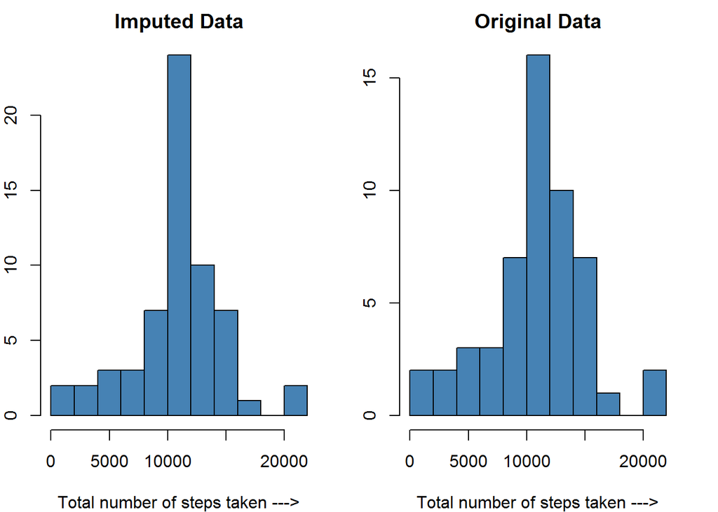

```r
new_total_steps_daywise <- tapply(imputed_data$steps, imputed_data$date, sum, na.rm = TRUE)
par(mar = c(4,2,2,2), mfrow = c(1,2))
hist(new_total_steps_daywise, main = "Imputed Data", xlab = "Total number of steps taken --->", ylab = "Frequency --->", col = "steel blue", breaks = 10)
hist(total_steps_daywise, main = "Original Data", xlab = "Total number of steps taken --->", ylab = "Frequency --->", col = "steel blue", breaks = 10)
```

```r
new_mean <- round(mean(new_total_steps_daywise), digits = 1)
new_median <- round(median(new_total_steps_daywise), digits = 1)
```

Imputation of the data has no effect on mean and a small change in median of the total number of steps taken.

### Are there differences in activity patterns between weekdays and weekends?

#### 1. Create a new factor variable in the dataset with two levels - “weekday” and “weekend” indicating whether a given date is a weekday or weekend day.

```r
alldata$DayType <- ifelse(alldata$weekday == "Saturday" | alldata$weekday == "Sunday", "Weekend", "Weekday")
head(alldata)
```

```
##   steps       date interval weekday DayType
## 1    NA 2012-10-01        0  Monday Weekday
## 2    NA 2012-10-01        5  Monday Weekday
## 3    NA 2012-10-01       10  Monday Weekday
## 4    NA 2012-10-01       15  Monday Weekday
## 5    NA 2012-10-01       20  Monday Weekday
## 6    NA 2012-10-01       25  Monday Weekday
```

#### 2. Make a panel plot containing a time series plot (i.e. type=“l”) of the 5-minute interval (x-axis) and the average number of steps taken, averaged across all weekday days or weekend days (y-axis).

```r
weekday_alldata <- alldata[alldata$DayType == "Weekday", ]
weekend_alldata <- alldata[alldata$DayType == "Weekend", ]
weekday_intervalwise <- tapply(weekday_alldata$steps, weekday_alldata$interval, mean, na.rm = TRUE)
weekend_intervalwise <- tapply(weekend_alldata$steps, weekend_alldata$interval, mean, na.rm = TRUE)
```

Plotting the line diagram for weekday and weekend

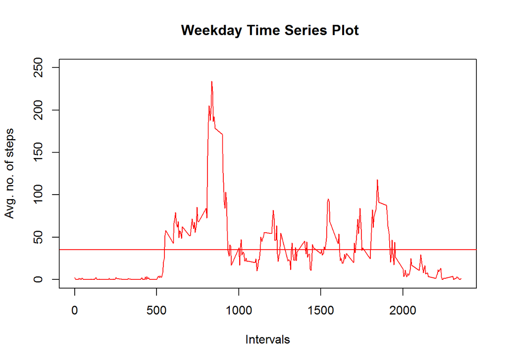

```r
plot(alldata$interval[1:288], weekday_intervalwise, col = "red", main = " Weekday Time Series Plot", xlab = "Intervals", ylab = "Avg. no. of steps", type = "l", ylim = c(0,250))
abline(h = mean(weekday_intervalwise), col = "red")
```

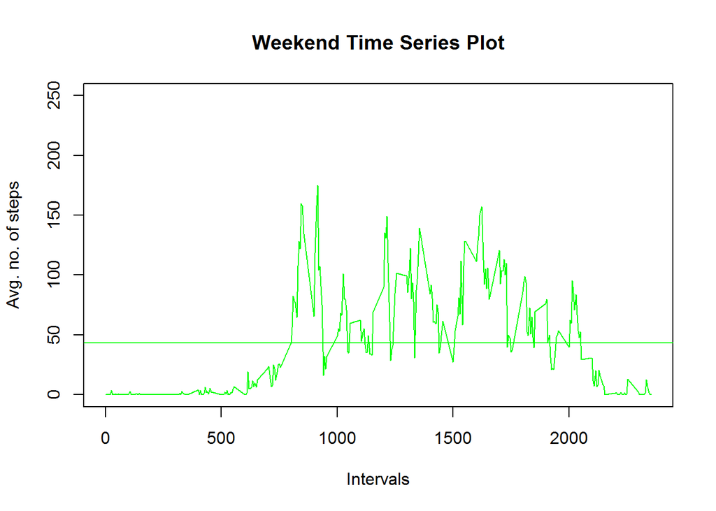

```r
plot(alldata$interval[1:288], weekend_intervalwise, col = "green", main = "Weekend Time Series Plot", xlab = "Intervals", ylab = "Avg. no. of steps", type = "l", ylim = c(0,250))
abline(h = mean(weekend_intervalwise), col = "green")
```